# Теорвер. Домашка. 22.02.17

```python
import numpy
import math
%pylab inline
```

## 8. Задача про дни рождения

Нужно найти максимум величины $X = E(\textit{количество трудовых человеко-дней})$ в зависимости от количество нанятых работников

$W_i$ - сколько человек трудится в $i$-ый день (т.е. либо все, либо никто)

Тогда $X = E(W_1 + W_2 + \cdots + W_{365}) = 365 \cdot E(W_1)$, т.к. дни независимы и неотличимы

Значит нужно найти масимум величины $E(W_1)$

$E(W_1) = k \cdot P(W_1)$, где $k$ - количество нанятых работников, $P(W_1)$ - вероятность того, что фиксированный день будет рабочим.

Вероятность того, что некоторый день будет рабочий легко вычислить - ни у одного работника не должно быть дня рождения в этот день, т.е. $P(W_1) = (1 - \frac{1}{365})^k$

Значит нужно максимизировать функцию $f(k) = E(W_1) = k \cdot (1 - \frac{1}{365})^k$

$f(k) = k \cdot e^{k \cdot \log(1 - \frac{1}{365})} = k \cdot e^{k \cdot \log C} \rightarrow f'(k) = e^{k \cdot \log C} + k \cdot e^{k \cdot \log C} \cdot \log C \rightarrow f'(k) = 0 \Leftrightarrow 1 + k \cdot \log C = 0 \rightarrow k = \frac{-1}{\log C} = \frac{1}{\log 1/C} = \frac{1}{\log 365 / 364}$

```python
1 / math.log(365 / 364)
```

```
364.4997713762012
```

Тогда максимум будет достигаться либо при $k = 364$ либо при $k = 365$. Чтобы определить точно, рассмотрим отношение $E_{364}(W_1) / E_{365}(W_1)$:

Пусть $d = 365$

$E_{d - 1}(W_1) / E_{d}(W_1) = \frac{(d - 1) \cdot (1 - 1/d)^{d - 1}}{d \cdot (1 - 1/d)^{d}} = \frac{d - 1}{d \cdot (1 - 1/d)} = \frac{d - 1}{d \cdot (d - 1) / d} = 1 \rightarrow $ максимум достигается в обоих этих точках.

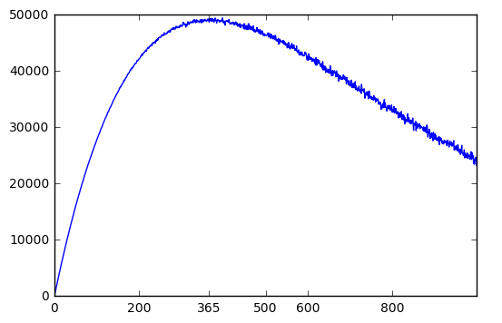

```python
days_in_year = 365
def sample_work_days(k):
    return days_in_year - len(set(numpy.random.randint(1, days_in_year, k)))

def sample_work_units(k):
    return sample_work_days(k) * k

def estimate_work_units(k):
    return np.mean([sample_work_units(k) for _ in range(100)])

xs = [i for i in range(10**3)]
ys = [estimate_work_units(i) for i in xs]
xticks([0, 200, 365, 500, 600, 800, 1000])
plot(xs, ys)
```

## Задача про мальчиков и девочек

Есть $a$ мальчиков и $b$ девочек. Посчитать среди всех возможных перестановок детей среднее число пар соседних мальчика и девочки.

У нас есть $15$ мест $1, 2, 3, \cdots 14, 15$. Для каждого места $i \in [1, 14]$ посчитаем верояность того, что на месте $i$ и $i + 1$ будут сидеть девочка и мальчик (или наоборот):

$P_i = 2 \cdot \frac{a}{a + b} \frac{b}{a + b - 1} = \frac{2ab}{(a + b)(a + b - 1)}$

Ясно, что интересующее нас матожидание $E = P_1 + P_2 + \cdots + P_{14} = \frac{2ab(a + b - 1)}{(a + b)(a + b - 1)} = \frac{2ab}{a + b}$

```python
a, b = 8, 7
def get_expectation(a, b):
    return 2 * a * b / (a + b)
print('8 boys, 7 girls: {}'.format(get_expectation(8, 7)))
print('3 boys, 4 girls: {}'.format(get_expectation(3, 4)))
```

```
8 boys, 7 girls: 7.466666666666667
3 boys, 4 girls: 3.4285714285714284
```

```python
from itertools import permutations

def estimate_expectation(a, b):
    def calc_pairs(p):
        return sum(list(map(lambda t: t[0]^t[1], zip(p, p[1:]))))

    kids = [0 for _ in range(a)] + [1 for _ in range(b)]
    return np.mean([calc_pairs(numpy.random.permutation(kids)) for _ in range(100000)])
print('8 boys, 7 girls: {}'.format(estimate_expectation(8, 7)))
print('3 boys, 4 girls: {}'.format(estimate_expectation(3, 4)))
```

```
8 boys, 7 girls: 7.46137
3 boys, 4 girls: 3.42536
```

## Задача про поезда

По однополосной линии едут $n = 100$ поездов, скорость каждого из которых постоянна и выбрана случайно из распределения $\xi$. $F_{\xi}$ - непрерывна. Найти количество караванов.

Нам нужно посчитать $E = E(\textit{количество караванов}) = E(\textit{количество лидирующих поездов})$. Опять воспользуемся линейностью матожидания: $E = P_1 + P_2 + \cdots + P_n$, где $P_i$ - вероятность того, что $i$-ый вагон лидирует.

Что из себя представляет лидирующий вагон? Это вагон, скорость которого не больше, чем скорости всех впереди идущих поездов. Тогда $P_i = P(\{v_i \le \min(v_{i+1}\cdots v_n) | v_i \in \xi\})$. Заметим, что вероятность того, что $i$-ый вагон, имея скорость $v_i$, будет лидером каравана, равна $P_i(v_i) = P(\{v_i \le \min(v_{i+1}\cdots v_n) | v_i \in \xi\})$ - что есть ни что иное, как функция распределения случайно величины, являющейся минимумом среди $k = n - i$ независимых случайных величин из одинакового распределения $\xi$.

Несложно вычислить функцию распределения такой случайной величины: $F_{\xi}^{k}(x) = 1 - (1 - F_{\xi}(x))^k$

Однако нас просят посчитать вероятность $P_i$, где $v_i$ принадлежит распределению $\xi$, а $\min(v_{i+1}\cdots v_n)$ - распределению минимумов.

Несложно записать соответствующий интеграл: $\int_0^{\infty}{(1 - F_{\xi}^{k}(x))dF(x)}$ ($(1 - F_{\xi}^{k}(x)$ - т.к. при фиксированном $x = v_i$ мы должны посчитать вероятность того, что $\min(\cdots) \ge v_i$)

Возьмем интеграл: $\int_0^{\infty}{(1 - F_{\xi}^{k}(x))dF(x)} = \int_0^{\infty}{(1 - (1 - (1 - F(x))^k))dF(x)} = \int_0^{\infty}{(1 - F(x))^kdF(x)} = [\textit{заменим функцию T(x) = 1 - F(x)}] = \int_0^{\infty}{T(x)^kd(1 - T(x))} = -\int_0^{\infty}{T(x)^kdT(x)} = -\frac{T(x)^{k + 1}}{k + 1}|_0^{\infty} = -(0 - \frac{1}{k + 1}) = \frac{1}{k + 1}$

Значит $P_i = \frac{1}{n - i + 1}$, а $E = \sum_1^n{\frac{1}{i}} = H(n)$ - сумма префикса гармонического ряда

```python
def calculate_caravans(velocity):
    return sum((velocity[i] <= min(velocity[i:]) for i in range(len(velocity))))
```

```python
def sample_trains(n, iterations):
    return numpy.mean([calculate_caravans(numpy.random.normal(size=n)) for _ in range(iterations)])
```

```python
print('Expected: {}'.format(sum([1 / i for i in range(1, 101)])))
print('Actual: {}'.format(sample_trains(100, 2000)))
```

```
Expected: 5.187377517639621
Actual: 5.1625
```